# First looks at RF and MI

PR

2024-08-05

#### Goals

##### Use Random Forest and Mutual Information analyses to understand BGC relationsips across synoptic sites

Both Random Forests (RF) and Mutual Information (MI) are designed to understand how multiple predictors relate to some dependent variable. Since we’re interested in how parameters relate to each other across various delineations (regions, sites, transect locations), we’ll be using these as our dependents. I’ll start with Random Forests because I have more experience with them and they’re easier to interpret IMO.

We’ll construct RF models for

1. CB v WLE
2. UP v TR v W
3. Each site

Because the goal is to understand relationships in biogeochemistry and not to predict a specific variable, we will not be splitting data into training and testing datasets. This means we **should not** interpret goodness-of-fit metrics as how well we can “predict” if a sample comes from a given location, but rather how well the variables used as predictors explain the variability in the dataset. This is something of a subtle difference, but I think an important one.

Note that I’m adding a white noise variable to all models. That’s there as a guide for interpreting which variables are contributing more to the model than random chance.

### Random forest classification model results

#### Between regions

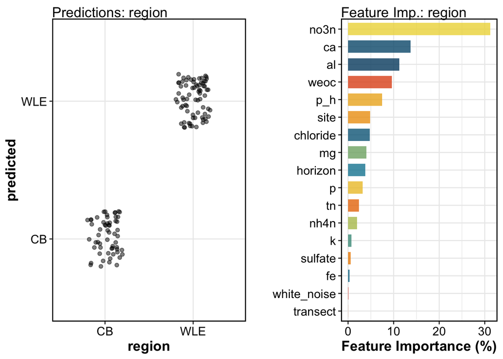

**Initial thoughts - Region**

- looks like region was correctly predicted for all data
- NO3 as the most important seems sensible, a little surprised it wasn’t salt-related though
- white noise near bottom (transect does not contribute more than random noise to the model so we should ignore it here)

#### Between transect locations

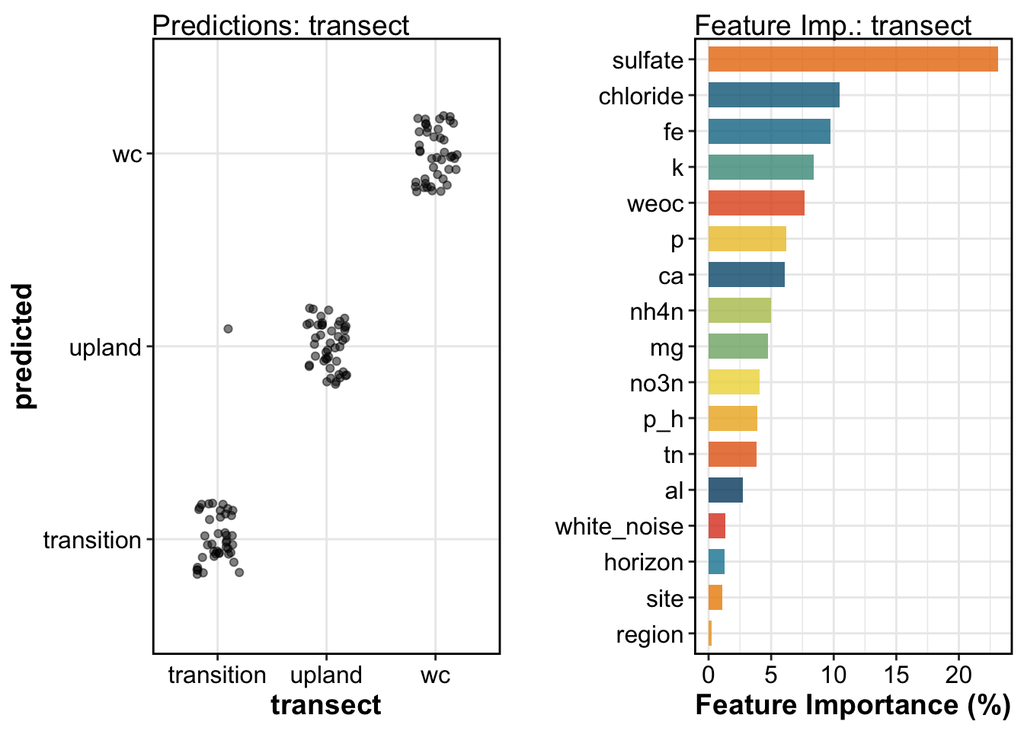

**Initial thoughts - Transect**

- all but one correctly classified (one Transition looked like Upland)
- sulfate is interesting, maybe the relative transition in redox is more consistent than the relative transition in other things across CB and WLE sites
- neither horizon nor region is important to this model

#### Between sites

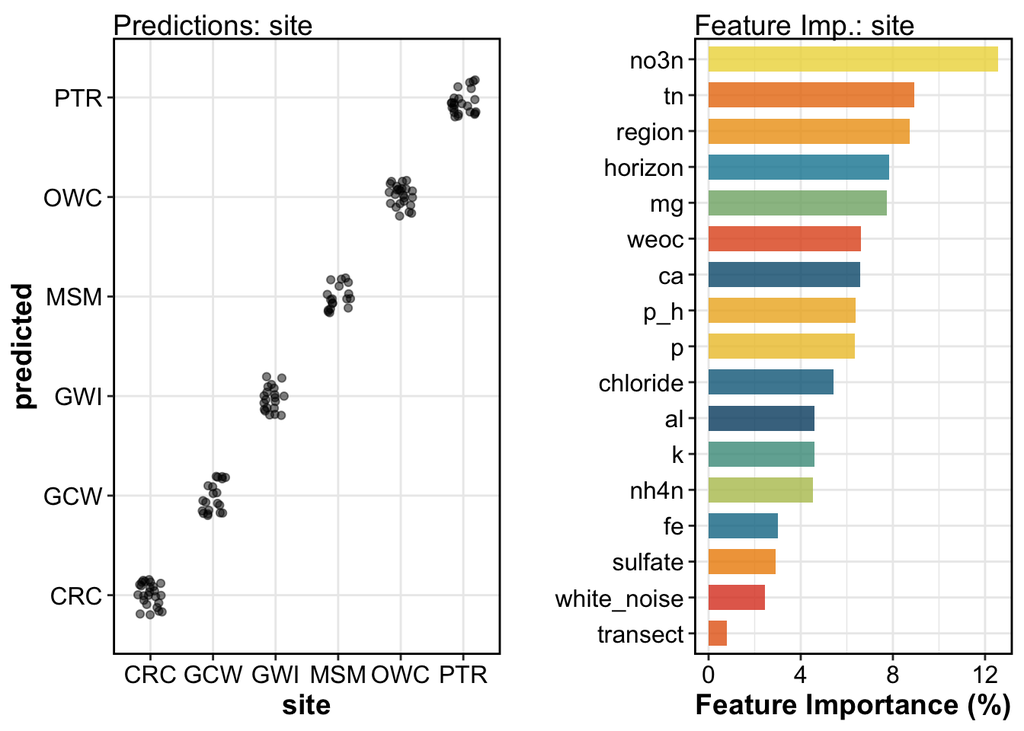

**Initial thoughts - Site**

- All correctly identified
- NO3 and TN as top variables followed by region and horizon seems like a nice mix! Much less “one variable to rule them all” vibes
- Transect not important to this model

#### A couple quick cautions

1. I haven’t done classification RF before, so 1) there’s probably a better way to quantify GOF, and 2) it would be good if we go this direction for me to take a bit of a deep dive into properly constructing and vetting an RF classification model.
2. I’m a little suspicious that the models performed “too” good… I was expecting them to get maybe half of the values right, 100% makes me suspicious.